# Analyzing Citi Bike Data

## by Shakhawat Hassan

## Investigation Overview

> In this project, my main point is to look at when the bikers take bikes during the week or hour, and what's their gender is. I also look into how long riders take bikes.

## Dataset Overview

> Citi bike is a public bike-sharing system and it is now owned by Lyft. Lyft operates Citi bike around New York City, and Jersey City, NJ. Citi bike bicycle sharing system was opened in May 2013 with 332 stations and 6,000 bikes. Due to the high volume of growth rate, Citi bike is expanding around the five boroughs of NYC. As of July 2017, there are 130,000 annual subscribers. The average is 48,315 rides per day in 2018. Rides per day/week/month/year are still growing rapidly.
> - Due to staying home order for Covid-19 there might be a decrease in rides per day.

## Total Rides Taken During the Week by Gender

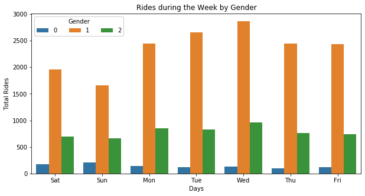

```python
plt.figure(figsize = [10, 5])
ax = sb.countplot(data = df_new, x = 'start_time_weekday', hue = 'gender')
ax.legend(loc = 2, ncol = 3, framealpha = 1, title = 'Gender')
plt.title('Rides during the Week by Gender')
plt.xlabel('Days')
plt.ylabel('Total Rides')
```

## Riders' Age vs User Type by Gender

> Both females and males prefer to get the annual membership.

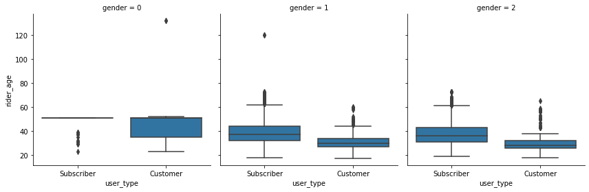

```python
plt.figure(figsize = [10, 10])
g = sb.FacetGrid(data = df_new, col = 'gender', size = 4)
g.map(sb.boxplot, 'user_type', 'rider_age')
```

## Weekly usage of Citi Bike per user type and gender

> Customers tend to take bike on Saturday and Sunday while subscribers tend to take bike on Wednesday

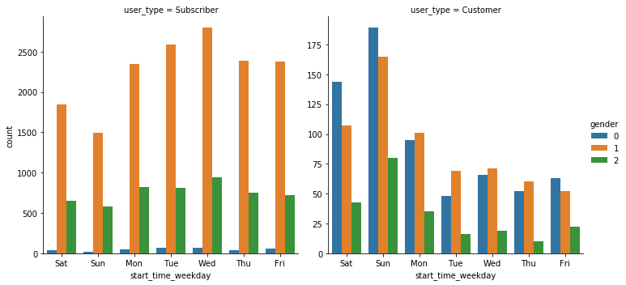

```python
g = sb.catplot(data= df_new, x = 'start_time_weekday', col = 'user_type', hue= 'gender', kind = 'count', sharey= False)
```

## Hourly usage of Citi Bike per user type and gender

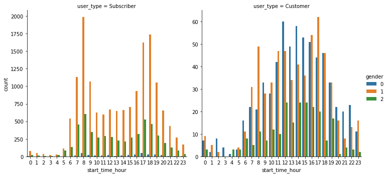

```python
g = sb.catplot(data= df_new, x = 'start_time_hour', col = 'user_type', hue= 'gender', kind = 'count', sharey= False)
```